# Strategic Pricing

Jiajin Zheng

2019-9-8

# The data

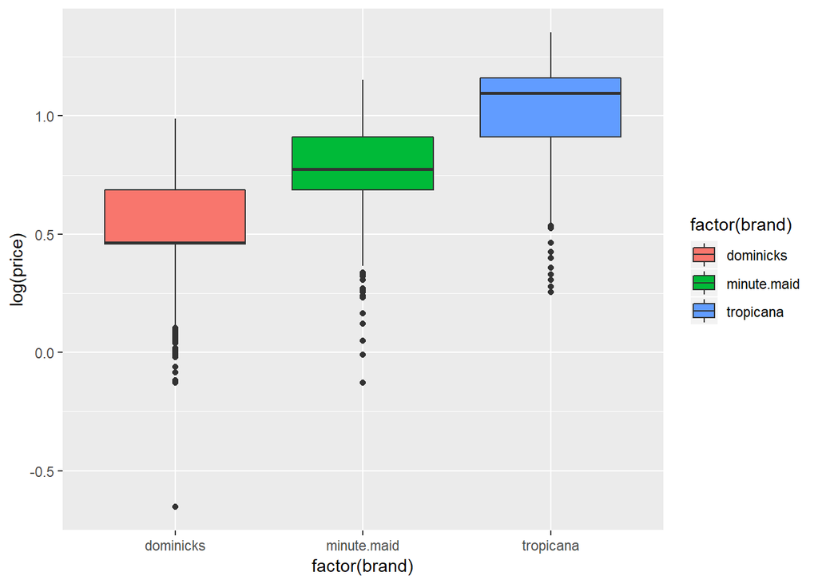

```r
oj <- read.csv("oj.csv")

#plot the price spread of the three orange juice brands
library(ggplot2)
ggplot(oj, aes(factor(brand), log(price))) +
  geom_boxplot(aes(fill = factor(brand)))
```

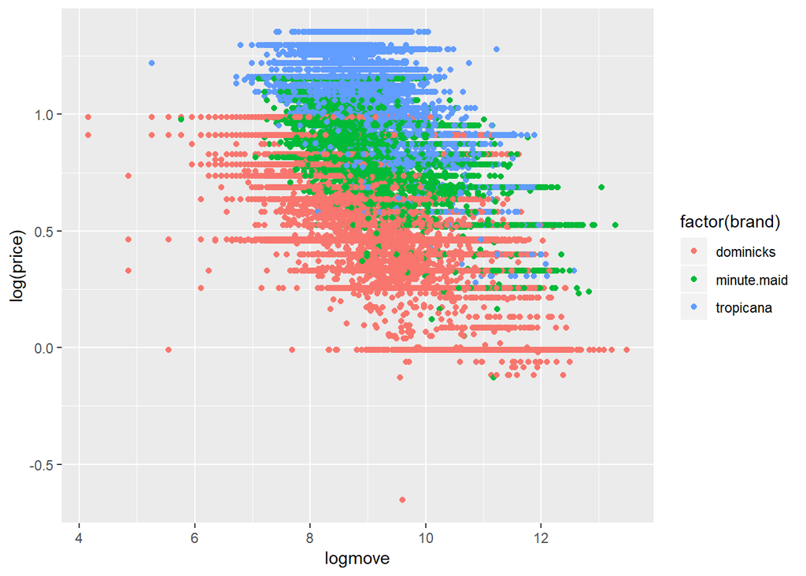

```r
#plot price and quantity sold spread
ggplot(oj, aes(logmove, log(price))) +
  geom_point(aes(color = factor(brand)))
```

# Models

```r
#a simple model
model <- lm(logmove ~ log(price)*brand*feat, data = oj)
summary(model)
```

```
##
## Call:
## lm(formula = logmove ~ log(price) * brand * feat, data = oj)
##
## Residuals:
##     Min      1Q  Median      3Q     Max
## -4.8893 -0.4290 -0.0091  0.4125  3.2368
##
## Coefficients:
##                                  Estimate Std. Error t value Pr(>|t|)
## (Intercept)                      10.40658    0.02335 445.668  < 2e-16 ***
## log(price)                       -2.77415    0.03883 -71.445  < 2e-16 ***
## brandminute.maid                  0.04720    0.04663   1.012    0.311
## brandtropicana                    0.70794    0.05080  13.937  < 2e-16 ***
## feat                              1.09441    0.03810  28.721  < 2e-16 ***
## log(price):brandminute.maid       0.78293    0.06140  12.750  < 2e-16 ***
## log(price):brandtropicana         0.73579    0.05684  12.946  < 2e-16 ***
## log(price):feat                  -0.47055    0.07409  -6.351 2.17e-10 ***
## brandminute.maid:feat             1.17294    0.08196  14.312  < 2e-16 ***
## brandtropicana:feat               0.78525    0.09875   7.952 1.90e-15 ***
## log(price):brandminute.maid:feat -1.10922    0.12225  -9.074  < 2e-16 ***
## log(price):brandtropicana:feat   -0.98614    0.12411  -7.946 2.00e-15 ***
## ---
## Signif. codes:  0 '***' 0.001 '**' 0.01 '*' 0.05 '.' 0.1 ' ' 1
##
## Residual standard error: 0.695 on 28935 degrees of freedom
## Multiple R-squared:  0.5354, Adjusted R-squared:  0.5352
## F-statistic:  3031 on 11 and 28935 DF,  p-value: < 2.2e-16
```

```r
#a model with the demographic variables
model1 <- lm(logmove ~ log(price)*brand*feat + AGE60 + EDUC + ETHNIC + INCOME + HHLARGE + WORKWOM + HVAL150 + SSTRDIST + SSTRVOL + CPDIST5 + CPWVOL5, data = oj)
summary(model1)
```

```
##
## Call:
## lm(formula = logmove ~ log(price) * brand * feat + AGE60 + EDUC +
##     ETHNIC + INCOME + HHLARGE + WORKWOM + HVAL150 + SSTRDIST +
##     SSTRVOL + CPDIST5 + CPWVOL5, data = oj)
##
## Residuals:
##     Min      1Q  Median      3Q     Max
## -5.2004 -0.3922 -0.0049  0.3786  2.9884
##
## Coefficients:
##                                   Estimate Std. Error t value Pr(>|t|)
## (Intercept)                      13.143435   0.329622  39.874  < 2e-16 ***
## log(price)                       -2.854302   0.036816 -77.528  < 2e-16 ***
## brandminute.maid                  0.092348   0.044158   2.091  0.03651 *
## brandtropicana                    0.772280   0.048102  16.055  < 2e-16 ***
## feat                              1.055010   0.036034  29.278  < 2e-16 ***
## AGE60                             2.044239   0.127506  16.032  < 2e-16 ***
## EDUC                              0.955931   0.101486   9.419  < 2e-16 ***
## ETHNIC                            0.643102   0.037229  17.274  < 2e-16 ***
## INCOME                           -0.279937   0.033300  -8.406  < 2e-16 ***
## HHLARGE                          -0.920092   0.230509  -3.992 6.58e-05 ***
## WORKWOM                          -0.424559   0.146824  -2.892  0.00384 **
## HVAL150                           0.357561   0.041803   8.554  < 2e-16 ***
## SSTRDIST                         -0.019979   0.001465 -13.634  < 2e-16 ***
## SSTRVOL                          -0.055948   0.009768  -5.728 1.03e-08 ***
## CPDIST5                           0.064160   0.006289  10.203  < 2e-16 ***
## CPWVOL5                          -0.500272   0.025703 -19.464  < 2e-16 ***
## log(price):brandminute.maid       0.753984   0.058086  12.981  < 2e-16 ***
## log(price):brandtropicana         0.713983   0.053736  13.287  < 2e-16 ***
## log(price):feat                  -0.405049   0.070053  -5.782 7.45e-09 ***
## brandminute.maid:feat             1.131698   0.077495  14.603  < 2e-16 ***
## brandtropicana:feat               0.746656   0.093353   7.998 1.31e-15 ***
## log(price):brandminute.maid:feat -1.079118   0.115559  -9.338  < 2e-16 ***
## log(price):brandtropicana:feat   -0.989109   0.117302  -8.432  < 2e-16 ***
## ---
## Signif. codes:  0 '***' 0.001 '**' 0.01 '*' 0.05 '.' 0.1 ' ' 1
##
## Residual standard error: 0.6568 on 28924 degrees of freedom
## Multiple R-squared:  0.5851, Adjusted R-squared:  0.5848
## F-statistic:  1854 on 22 and 28924 DF,  p-value: < 2.2e-16
```

```r
#all demographic variables are significant according to the t-values

#out-of-sample predictions
library(dplyr)
set.seed(437)
#sample 80% of the data for the training sets
n <- 28947*.8
oj_train <- sample_n(oj, n)
oj_test <- setdiff(oj, oj_train)

#the two models again
model_noDemo <- lm(logmove ~ log(price)*brand*feat, data = oj_train)

model_demo <- lm(logmove ~ log(price)*brand*feat + AGE60 + EDUC + ETHNIC + INCOME + HHLARGE + WORKWOM + HVAL150 + SSTRDIST + SSTRVOL + CPDIST5 + CPWVOL5, data = oj_train)

P_noDemo <- predict(model_noDemo, oj_test)
P_demo <- predict(model_demo, oj_test)

#mean squared errors of out-of-sample predictions
MSE_noDemo <- (1/5790)*sum((oj_test$logmove-P_noDemo)^2)
MSE_demo <- (1/5790)*sum((oj_test$logmove-P_demo)^2)
print(MSE_noDemo)
```

```
## [1] 0.474766
```

```r
print(MSE_demo)
```

```
## [1] 0.4258873
```

The model with demographic variables has a lower MSE and fits the data better.

# The effects of education and household sizes on demand

```r
#EDUC: fraction of shoppers with advanced education
#HHLARGE: fraction of households that are large
summary(oj$EDUC)
```

```
##    Min. 1st Qu.  Median    Mean 3rd Qu.    Max.
## 0.04955 0.14598 0.22939 0.22522 0.28439 0.52836
```

```r
summary(oj$HHLARGE)
```

```
##    Min. 1st Qu.  Median    Mean 3rd Qu.    Max.
## 0.01351 0.09794 0.11122 0.11560 0.13517 0.21635
```

```r
#Using the coefficient estimates from model1,
#the effect of EDUC increasing from the median
#to the 3rd quartile

beta_ED <- coef(model1)["EDUC"]
EDincrease <- summary(oj$EDUC)["3rd Qu."] - summary(oj$EDUC)["Median"]
exp(beta_ED * EDincrease) #exp because quantity was logged
```

```
##     EDUC
## 1.053987
```

```r
#Similarly, with HHLARGE increasing
#from the median to the 3rd quartile
beta_HH <- coef(model1)["HHLARGE"]
HHincrease <- summary(oj$HHLARGE)["3rd Qu."] - summary(oj$HHLARGE)["Median"]
exp(beta_HH * HHincrease)
```

```
##  HHLARGE
## 0.978208
```

This suggests education is more important in predicting demand. But let’s see what happens if we build a model with EDUC and HHLARGE interacting with log(price)

```r
model2 <- lm(logmove ~ log(price)*brand*feat + AGE60 + EDUC*log(price) + ETHNIC + INCOME + HHLARGE*log(price) + WORKWOM + HVAL150 + SSTRDIST + SSTRVOL + CPDIST5 + CPWVOL5, data = oj)

coef(model2)["log(price):EDUC"]
```

```
## log(price):EDUC
##        3.516905
```

```r
coef(model2)["log(price):HHLARGE"]
```

```
## log(price):HHLARGE
##          -5.347214
```

These two coefficients suggest that more highly educated people are less sensitive to prices (perhaps they care more about quality) and large families care more about prices (probably because of the large quantities they consume).

```r
coef(model2)["EDUC"]
```

```
##     EDUC
## -1.90294
```

```r
coef(model2)["HHLARGE"]
```

```
##  HHLARGE
## 3.371095
```

Education in general drives down demand for orange juice, but education’s negative correlation with price sensitivity was not separated from it in the first model. In other words, the negative effect of education on demand was understated, so much so that it was estimated as positive. Similarly with HHLARGE, large households overall have higher demand for orange juice, but their higher price sensitivity was not separated from HHLARGE in the first model, and its effect was underestimated.

# Intertemporal substitution

```r
#construct a lagged_price variable from the week before
df1 <- oj
df1$week <- df1$week+1

df2 <- merge(oj, df1,
             by=c("brand", "store", "week"))
df2 <- df2[,-c(21:31)] #get rid of repeated variables

names(df2)[6] <- "price"
names(df2)[20] <- "lagged_price"

summary(lm(logmove.x ~ log(price) + log(lagged_price), data = df2))
```

```
##
## Call:
## lm(formula = logmove.x ~ log(price) + log(lagged_price), data = df2)
##
## Residuals:
##     Min      1Q  Median      3Q     Max
## -4.9174 -0.5173 -0.0191  0.5085  3.7825
##
## Coefficients:
##                   Estimate Std. Error t value Pr(>|t|)
## (Intercept)        9.98930    0.01536  650.30   <2e-16 ***
## log(price)        -2.79038    0.02295 -121.56   <2e-16 ***
## log(lagged_price)  1.74826    0.02285   76.51   <2e-16 ***
## ---
## Signif. codes:  0 '***' 0.001 '**' 0.01 '*' 0.05 '.' 0.1 ' ' 1
##
## Residual standard error: 0.825 on 28005 degrees of freedom
## Multiple R-squared:  0.3461, Adjusted R-squared:  0.3461
## F-statistic:  7412 on 2 and 28005 DF,  p-value: < 2.2e-16
```

Previous week’s price is positively correlated with this week’s sold quantity. This makes sales less attractive because this suggests that sales would boost this week’s quantity but depress next period’s performance - people might just buy more now and use later (same net quantity), resulting in revenue loss for the store.

# Trees for elasticities

```r
#add other brands' prices to each row
library(data.table)
oj2 <- dcast(oj, store + week ~ brand, value.var="price")
oj_merge <- merge(oj, oj2, by=c("week", "store"))

oj_merge$Q <- exp(oj_merge$logmove) #add quantity

#add sales-weighted price for each store-week
library(plyr)
swp <- ddply(oj_merge, c("store", "week"), function(oj_merge) c(swp = weighted.mean(oj_merge$price, oj_merge$Q)))

oj_swp <- merge(oj_merge, swp, by=c("week", "store"))
```

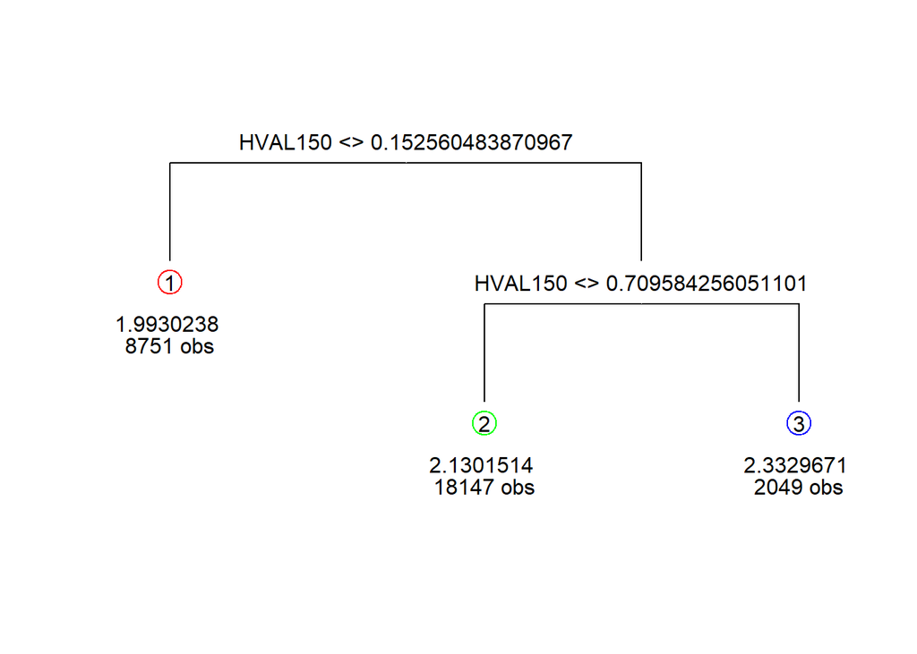

```r
#construct a tree
dataToPass <- oj_swp[,c("swp","AGE60","EDUC","ETHNIC","INCOME","HHLARGE","WORKWOM","HVAL150","SSTRDIST","SSTRVOL","CPDIST5","CPWVOL5")]

library(rpart)
fit <- rpart(as.formula(swp ~ .),data=dataToPass,method="anova",cp=0.007)

library(maptree)
draw.tree(fit)
```

```r
#subset the data by leaf
dataToPass$leaf = fit$where
oj_swp$leaf <- dataToPass$leaf
count(oj_swp$leaf)
```

```
##   x  freq
## 1 2  8751
## 2 4 18147
## 3 5  2049
```

```r
oj_leaf2 <- subset(oj_swp, leaf==2)
oj_leaf4 <- subset(oj_swp, leaf==4)
oj_leaf5 <- subset(oj_swp, leaf==5)
```

**own-price elasticities in each leaf**

```r
glm(logmove ~ log(price)*brand*feat, data=oj_leaf2)
```

```
##
## Call:  glm(formula = logmove ~ log(price) * brand * feat, data = oj_leaf2)
##
## Coefficients:
##                      (Intercept)                        log(price)
##                         10.69432                          -2.83435
##                 brandminute.maid                    brandtropicana
##                          0.07093                           0.80881
##                             feat       log(price):brandminute.maid
##                          1.15089                           0.35607
##        log(price):brandtropicana                   log(price):feat
##                          0.13414                          -0.55800
##            brandminute.maid:feat               brandtropicana:feat
##                          1.02950                           0.61614
## log(price):brandminute.maid:feat    log(price):brandtropicana:feat
##                         -0.82352                          -0.83239
##
## Degrees of Freedom: 8750 Total (i.e. Null);  8739 Residual
## Null Deviance:       10530
## Residual Deviance: 4481  AIC: 19000
```

```r
glm(logmove ~ log(price)*brand*feat, data=oj_leaf4)
```

```
##
## Call:  glm(formula = logmove ~ log(price) * brand * feat, data = oj_leaf4)
##
## Coefficients:
##                      (Intercept)                        log(price)
##                          10.2240                           -2.6113
##                 brandminute.maid                    brandtropicana
##                           0.1394                            0.9041
##                             feat       log(price):brandminute.maid
##                           1.1252                            0.7191
##        log(price):brandtropicana                   log(price):feat
##                           0.6134                           -0.5260
##            brandminute.maid:feat               brandtropicana:feat
##                           1.1291                            0.6777
## log(price):brandminute.maid:feat    log(price):brandtropicana:feat
##                          -1.0527                           -0.8664
##
## Degrees of Freedom: 18146 Total (i.e. Null);  18135 Residual
## Null Deviance:       17030
## Residual Deviance: 7505  AIC: 35500
```

```r
glm(logmove ~ log(price)*brand*feat, data=oj_leaf5)
```

```
##
## Call:  glm(formula = logmove ~ log(price) * brand * feat, data = oj_leaf5)
##
## Coefficients:
##                      (Intercept)                        log(price)
##                          10.2824                           -3.0412
##                 brandminute.maid                    brandtropicana
##                           0.4594                            1.5577
##                             feat       log(price):brandminute.maid
##                           0.9594                            1.1851
##        log(price):brandtropicana                   log(price):feat
##                           1.0762                           -0.2215
##            brandminute.maid:feat               brandtropicana:feat
##                           0.9571                            0.2228
## log(price):brandminute.maid:feat    log(price):brandtropicana:feat
##                          -1.1427                           -0.5409
##
## Degrees of Freedom: 2048 Total (i.e. Null);  2037 Residual
## Null Deviance:       2428
## Residual Deviance: 809.7     AIC: 3938
```

Generally, own-price elasticities decrease as house values increase, with the exception of dominicks in the most expensive neighborhood (leaf 5)–the own price sensitivity of its demand is higher than the other two leaves.

**own- and cross-price elasticities in each leaf**

```r
# HVAL150 < 0.15
oj_leaf2_D <- subset(oj_leaf2, brand=="dominicks")
oj_leaf2_MM <- subset(oj_leaf2, brand=="minute.maid")
oj_leaf2_T <- subset(oj_leaf2, brand=="tropicana")

leaf2_D <- glm(logmove ~ log(price)*feat + log(minute.maid)*feat + log(tropicana)*feat, data=oj_leaf2_D)
leaf2_MM <- glm(logmove ~ log(price)*feat + log(dominicks)*feat + log(tropicana)*feat, data=oj_leaf2_MM)
leaf2_T <- glm(logmove ~ log(price)*feat + log(minute.maid)*feat + log(dominicks)*feat, data=oj_leaf2_T)

M2 = matrix(
  c(leaf2_D$coefficients["log(price)"], leaf2_MM$coefficients["log(dominicks)"], leaf2_T$coefficients["log(dominicks)"], leaf2_D$coefficients["log(minute.maid)"], leaf2_MM$coefficients["log(price)"], leaf2_T$coefficients["log(minute.maid)"], leaf2_D$coefficients["log(tropicana)"], leaf2_MM$coefficients["log(tropicana)"], leaf2_T$coefficients["log(price)"]), nrow=3, ncol=3
)
colnames(M2) <- paste(c("Dominicks", "Minute.Maid", "Tropicana"))
rownames(M2) <- paste(c("Dominicks", "Minute.Maid", "Tropicana"))
print(M2)
```

```
##              Dominicks Minute.Maid  Tropicana
## Dominicks   -2.9268781   0.8636501 -0.3987226
## Minute.Maid  0.6419279  -2.8206616  0.2601594
## Tropicana    0.1686197   0.1553601 -2.7891045
```

```r
# 0.15 < HVAL150 < 0.71
oj_leaf4_D <- subset(oj_leaf4, brand=="dominicks")
oj_leaf4_MM <- subset(oj_leaf4, brand=="minute.maid")
oj_leaf4_T <- subset(oj_leaf4, brand=="tropicana")

leaf4_D <- glm(logmove ~ log(price)*feat + log(minute.maid)*feat + log(tropicana)*feat, data=oj_leaf4_D)
leaf4_MM <- glm(logmove ~ log(price)*feat + log(dominicks)*feat + log(tropicana)*feat, data=oj_leaf4_MM)
leaf4_T <- glm(logmove ~ log(price)*feat + log(minute.maid)*feat + log(dominicks)*feat, data=oj_leaf4_T)

M4 = matrix(
  c(leaf4_D$coefficients["log(price)"], leaf4_MM$coefficients["log(dominicks)"], leaf4_T$coefficients["log(dominicks)"], leaf4_D$coefficients["log(minute.maid)"], leaf4_MM$coefficients["log(price)"], leaf4_T$coefficients["log(minute.maid)"], leaf4_D$coefficients["log(tropicana)"], leaf4_MM$coefficients["log(tropicana)"], leaf4_T$coefficients["log(price)"]), nrow=3, ncol=3
)
colnames(M4) <- paste(c("Dominicks", "Minute.Maid", "Tropicana"))
rownames(M4) <- paste(c("Dominicks", "Minute.Maid", "Tropicana"))
print(M4)
```

```
##              Dominicks Minute.Maid  Tropicana
## Dominicks   -2.7398473   0.9107199 -0.1453081
## Minute.Maid  0.5608848  -2.2645998  0.3504499
## Tropicana    0.1103159   0.2547604 -2.0884477
```

```r
# HVAL150 > 0.71
oj_leaf5_D <- subset(oj_leaf5, brand=="dominicks")
oj_leaf5_MM <- subset(oj_leaf5, brand=="minute.maid")
oj_leaf5_T <- subset(oj_leaf5, brand=="tropicana")

leaf5_D <- glm(logmove ~ log(price)*feat + log(minute.maid)*feat + log(tropicana)*feat, data=oj_leaf5_D)
leaf5_MM <- glm(logmove ~ log(price)*feat + log(dominicks)*feat + log(tropicana)*feat, data=oj_leaf5_MM)
leaf5_T <- glm(logmove ~ log(price)*feat + log(minute.maid)*feat + log(dominicks)*feat, data=oj_leaf5_T)

M5 = matrix(
  c(leaf5_D$coefficients["log(price)"], leaf5_MM$coefficients["log(dominicks)"], leaf5_T$coefficients["log(dominicks)"], leaf5_D$coefficients["log(minute.maid)"], leaf5_MM$coefficients["log(price)"], leaf5_T$coefficients["log(minute.maid)"], leaf5_D$coefficients["log(tropicana)"], leaf5_MM$coefficients["log(tropicana)"], leaf5_T$coefficients["log(price)"]), nrow=3, ncol=3
)
colnames(M5) <- paste(c("Dominicks", "Minute.Maid", "Tropicana"))
rownames(M5) <- paste(c("Dominicks", "Minute.Maid", "Tropicana"))
print(M5)
```

```
##               Dominicks Minute.Maid  Tropicana
## Dominicks   -3.05965103  0.47345065 -0.1774728
## Minute.Maid  0.22078703 -2.00138931  0.1818225
## Tropicana   -0.01313409  0.03632401 -1.9694570
```

With regard to cross-price elasticities, Dominicks customers are more sensitive to Minute Maid prices in the second leaf than in the first, but Minute Maid customers are less sensitive to Dominicks prices in the second leaf; cross-price elasticities between Minute Maid and Tropicana are higher in the second leaf than the first; cross-price elasticities between Dominicks and Minute Maid as well as between Minute Maid and Tropicana are the lowest in leaf 5.

**Implications for price markups**

The markups should be smallest in the leaf with the highest own-price elasticities. Cross-price elasticities seem to reflect own-price elasticities–the overall trend is they decrease together. This implies that stores can have higher markups across brands in the least cross-price elastic leaf. Stores in the lowest leaf should have sales at the same time to increase overall oj sales (and not just pull customers between brands); stores in the highest leaf can have sales at different time without worrying too much about competition between brands.